# PS3

```python
import numpy as np
import pandas as pd
import matplotlib.pyplot as plt
%matplotlib inline
from itertools import product
from IPython.core.display import display, HTML
```

**1** Wakanda and Zakanda are two neighboring countries. Wakanda has a highly advanced technology, whereas, Zakanda has a lower level of technology and lower income per capita. In the usual setting, we would expect Zakanda to learn about Wakanda's technology but Wakanda has been successfully hiding its technology from the rest of the world for centuries. At time $t=0$, Wakanda has a productivity of 10, $A_w = 10$, and 20% of its labor force engage in R&D, $\gamma_{A,W} = .2$. Zakanda, on the other hand, has a productivity level of 6, $A_Z=6$, and 10% of its population engages in R&D, $\gamma_{A,Z}=.1$. Each country has a labor force equal to 1, $L=1$. Price of invention in each country is equal to 10, $\mu = 10$. Along the line, the following events take place:

- After long soul searching, at time $t=10$, King T'Challa of Wakanda decides to open up Wakanda's technology to Zakanda.
- King T'Chala observes Zakanda's development for 10 periods. But, he is surprised that Zakanda did not imitate Wakanda's technology and it grows at its former pace, as before time $t=10$. He appoints his sister and Chief Scientist of Wakanda, Shuri, as his technology ambassador to Zakanda at time $t=20$.
- With the help of Shuri, Zakanda is able to imitate Wakanda's technology with a cost of copying equal to $\mu_{c} = \mu_i \left(\frac{A_W}{A_Z} \right)^{-1/2}.$ Shuri, who is highly intelligent and witty, convinces Zakanda to increase the fraction of workers engaged in R&D to 15%, $\gamma_{A,Z}=.15$
- After observing the progress made since $t=20$, Zakandans increase the fraction of labor force engaging R&D to 22%, $\gamma_{A,Z}=.22 $ at time $t=50.$

a. Using the appropriate models we covered in Lecture (You need to employ one-country model of technology creation and growth and two-country model of technology creation and growth in answering this question.), simulate and plot Wakanda and Zakanda productivities and income per capita levels from $t=0$ to $t=250$ considering the events took place. Briefly comment on your graphs. In your graphs, make sure to highlight each event.

b. What might have prevented Zakanda from imitating Wakanda's technology from time $t=10$ to time $t=20$? Briefly explain. (In this question, I expect you to read section 8.4 (Barrier to international technology transfer) of Weil (2013).)

[figure not shown]

#### Solution

Notice that until $t=20$, Wakanda's technology is hidden from Zakanda. Hence, we need to consider technological progress in each of the countries separately as our one country model. Therefore, to calculate Wakanda's productivity and income over time, first we calculate productivity growth rate:

$$ \hat{A_w}(t) = \frac{\gamma_{A,w} L }{\mu}$$

Then, we calculate output:

$$ y_{w}(t) = A_w(t)(1-\gamma_{A,w}) $$

Then, using the growth rate we calculated and current productivity level, we can calculate next period's productivity:

$$ A_w(t+1) = A_w(t)(1+\hat{A_w}(t))$$

Starting from $t=0$, we repeat these calculations 20 times to get productivity and income of Wakanda for $t=0,20$

We calculate Zakanda's productivity and income until t=19 as we did for Wakanda:

$$ \hat{A_z}(t) = \frac{\gamma_{A,z} L }{\mu}$$$$ y_{z}(t) = A_z(t)(1-\gamma_{A,z}) $$$$ A_z(t+1) = A_z(t)(1+\hat{A_z}(t))$$

Repeat the above calculations 19 times.

Now, at time $t=20$, we observe 2 important developments. First, Zakanda begins imitating Wakanda's technology, and second, Zakanda increases share of labor force engaged in R&D to .15, notated as $\gamma_{A,z}^n$, where $n$ represents 'new'. However, as Wakanda is the technology leader, nothing changes for Wakanda, and we can keep calculating Wakanda's income and output as we did before until $t=50$. Now, Zakanda's productivity growth can be calculated as follows:

First, calculate the cost of imitation at time $t$, $$\mu_{c}(t) = \mu \left(\frac{A_w(t)}{A_z(t)} \right)^{-1/2}$$

Notice that cost of imitation depends on the ratio of productivities in these countries. Hence, we need to calcualte a new cost of imitation at each time $t$. Then we can calculate productivity growth rate in Zakanda,

$$ \hat{A_z}(t) = \frac{\gamma_{A,z}^n L }{\mu_c(t)}$$

Lastly, we can can calculate output in Zakanda,

$$ y_{z}(t) = A_z(t)(1-\gamma_{A,z}^n) $$

Lastly we need to repeat this from $t=20$ to $t=50$. At time $t=50$, Zakanda increases the faraction of labor force engaged in R&D to .22. Now, we repeat the above process with the most recent $\gamma_{A,z}$. This will go on for a while, until the point Zakanda's productivity surpases Wakanda's productivity. Then, Zakanda will become the technology leader. Therefore, after that time, cost of innovation in Zakanda will be equal to cost of invention, and cost of innovation in Wakanda will be equal to cost of copying.

$$\mu_{c}(t) = \mu \left(\frac{A_z(t)}{A_w(t)} \right)^{-1/2}$$$$ \hat{A_z}(t) = \frac{\gamma_{A,z}^n L }{\mu}$$$$ \hat{A_w}(t) = \frac{\gamma_{A,w}^n L }{\mu_c(t)}$$

We will iterate this process until $t=250.$

```python
# First I define the parameter values in Python #
T  = 300 # number of time periods
mu = 10 # cost of invention
L = 1 # labor force
gamma_w = .2*np.ones(T) # fraction of workers engaged in R&D in Wakanda
# fraction of workers engaged in R&D in Zakanda
gamma_z = np.zeros(T)
for t in range(T):
    if t<20:
        gamma_z[t] = .1
    elif 20<=t<50:
        gamma_z[t] = .15
    else:
        gamma_z[t] = .22
#gamma_z = np.array([.1 if t<20 else .22 for t in range(T)])
A_w = np.zeros(T) # productivity in Wakanda, it will be replaced by actual values
A_w[0] = 10
A_z = np.zeros(T) # productivity in Zakanda, it will be replaced by actual values
A_z[0] = 6
A_z_hat=np.zeros(T-1)  # productivity growth in Zakanda, it will be replaced by actual values
A_w_hat=np.zeros(T-1)   # productivity growth in Wakanda, it will be replaced by actual values
```

```python
# this is the algorithm I described above
for t in range(T-1):
    # when t<10, each country is independent
    if t<20:
        A_w_hat[t] = gamma_w[t]*L/mu
        A_w[t+1] = A_w[t]*(1+A_w_hat[t])
        mu_c = mu
        A_z_hat[t] = gamma_z[t]*L/mu_c
        A_z[t+1] = A_z[t]*(1+A_z_hat[t])
    # after t > 20, if the productivity of Wakanda is greater than Zakanda's,
    # Wakanda is the technology leader, and Zakanda enjoys copying
    elif (A_w[t]>A_z[t]):
        A_w_hat[t] = gamma_w[t]*L/mu
        A_w[t+1] = A_w[t]*(1+A_w_hat[t])
        mu_c = mu*(A_w[t]/A_z[t])**(-1/2)
        A_z_hat[t] = gamma_z[t]*L/mu_c
        A_z[t+1] = A_z[t]*(1+A_z_hat[t])
    # after t > 20, if the productivity of Zakanda is greater than Wakanda's,
    # Zakanda is the technology leader, and Wakanda enjoys copying
    else:
        A_z_hat[t] = gamma_z[t]*L/mu
        A_z[t+1] = A_z[t]*(1+A_z_hat[t])
        mu_c = mu*(A_z[t]/A_w[t])**(-1/2)
        A_w_hat[t] = gamma_w[t]*L/mu_c
        A_w[t+1] = A_w[t]*(1+A_w_hat[t])

y_w = (1-gamma_w)*A_w # output in Wakanda
y_z = (1-gamma_z)*A_z # output in Zakanda
```

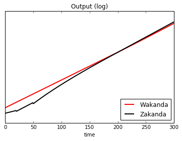

```python
plt.plot(np.log(y_w),'r',linewidth=2,label="Wakanda")
plt.plot(np.log(y_z),'k',linewidth=2,label='Zakanda')
plt.xlabel('time')
plt.yticks([])
plt.title('Output (log)')
plt.legend(loc='lower right')
plt.savefig('Output_zoom.pdf')
```

Not that Zakanda's output jumps down twice as a result of higher fraction of labor force engaged in R&D. However, after the jumps, Zakanda grows at a higher rate than before. Eventually, Zakanda catches Wakanda.

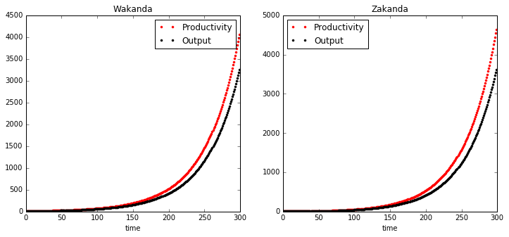

```python
# let's plot each country separately
num_rows, num_cols = 1 ,2
fig, axes = plt.subplots(num_rows, num_cols, figsize=(12, 5))
axes[0].plot(range(T),A_w,'r.',linewidth=2,label='Productivity')
axes[0].plot(range(T),y_w,'k.',linewidth=2,label='Output')
axes[0].set_title('Wakanda')
axes[0].legend(loc='best')
axes[0].set_xlabel('time')
axes[1].plot(range(T),A_z,'r.',linewidth=2,label='Productivity')
axes[1].plot(range(T),y_z,'k.',linewidth=2,label='Output')
axes[1].set_title('Zakanda')
axes[1].legend(loc='best')
axes[1].set_xlabel('time')
plt.savefig('graphs1.pdf')
```

Zakanda's productivity and income increases until t=20. As Zakanda begins imitating Wakanda's technology, it is able to increase its productiviity at higher rates. We also observe jump downs in Zakanda's output at $t=20$ and at $t=50$ as Zakanda increases fraction of labor force engaged in R&D. This leads to a temporary reduction in output, but higher productivity achieved in the subsequent periods compensantes for the reduced production workers and Zakanda enjoys higher output levels.

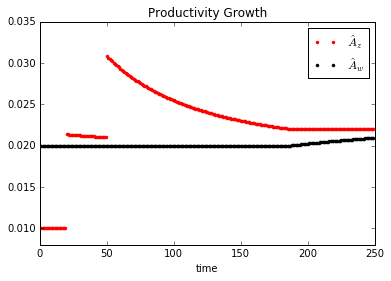

```python
# now let's look at the productivity growth rates
plt.plot(A_z_hat[:250],'r.',linewidth=2,label=r'$\hat{A}_z$')
plt.plot(A_w_hat[:250],'k.',linewidth=2,label=r'$\hat{A}_w$')
plt.legend(loc='best')
plt.xlabel('time')
plt.ylim(ymin=0.008)
plt.title('Productivity Growth')
```

```python
productivity = pd.DataFrame({'Productivity (Wakanda)':A_w[:250],
                            'Productivity (Zakanda)':A_z[:250],
                           'Output per worker (Wakanda)':y_w[:250],
                            'Output per worker (Zakanda)':y_z[:250],
                            'Productivity Growth (Wakanda)':A_w_hat[:250],
                            'Productivity Growth (Zakanda)':A_z_hat[:250]})
```

```python
productivity.to_csv('ps3-q1.csv')
```

**2)** Suppose you work as a research assistant for an economics professor. She wants to investigate the impact of the number of researhers on the growth rate of productivity. She wants you to collect data on number of researchers in OECD countries and number of patents awarded by European Patent Office (EPO) to inventors from the OECD countries. In particular, she wants you to go to: https://stats.oecd.org, and download data

- i) on the full-time equivalent number of researchers working in any sector of employment, doing R&D in any field,
- ii) on the number of patents granted by EPO in any technology domain,

for each country from 1981 to present. Usually, once an invention is made, it takes a few years before a patent for the invention is granted. In this question, use the date closest to the invention for the time of patent.

a) Download the data your professor requested.

b) Plot total full-time equivalent number of researchers (include every researcher working in any sector of employment and doing R&D in any field of R&D, and investors from any country on the data) over time (1981-2012).

c) Plot the total number of patents granted by EPO to inventors from any country in the World over time (1981-2012).

d) Plot the total number of patents granted by EPO to inventors from the countries on the dataset i) over time (1981-2012).

e) Using the total number of patents you calculated in part d), calculate the annual growth rates of the number of patents at each year. Plot the growth rates over time.

f) Considering all the graphs you plotted, does the data show evidence in favor of or againts the following formula of growth rate of productivity: $\hat{A} \equiv \frac{\dot{A}}{A} = \frac{L_A}{\mu}$?

I downloaded the researher data and the patent data as shown in the screenshots:

[figure not shown]

Then, make the following selections, make sure you adjust the time period as well:

[figure not shown]

```python
# Load our datasets
# Numer of patents
patents = pd.read_csv('patents.csv')
# Number of researchers and R&D personnel
persons = pd.read_csv('persons.csv')
```

First, understand our datasets.

```python
# These are Sector of employment categories. We will choose Toral intramural.
persons['Sector of employment'].unique()
```

```
array(['Total intramural', 'Business enterprise', 'Government',
       'Higher education', 'Private non-profit'], dtype=object)
```

```python
# These are Field of R&D categories. We will choose Total.
persons['Field of R&D'].unique()
```

```
array(['Total', 'Natural sciences and engineering', 'Natural sciences',
       'Engineering and technology', 'Medical and health sciences',
       'Agricultural and veterinary sciences',
       'Social sciences, humanities, and the arts', 'Social sciences',
       'Humanities and the arts', 'Not elsewhere classified'],
      dtype=object)
```

```python
# There are two measures of number of researchers: human count (HC) and full-time equivalent
# We will choose FTE
persons['MEASURE'].unique()
```

```
array(['FTE', 'HC'], dtype=object)
```

```python
# We will select all the genders, Total.
persons['Gender'].unique()
```

```
array(['Total', 'Female'], dtype=object)
```

```python
# These are set of countries in the csv version of the data I downloaded.
# However, you will see that
persons.COUNTRY.unique()
```

```
array(['AUS', 'AUT', 'BEL', 'CAN', 'CZE', 'DNK', 'FIN', 'FRA', 'DEU',
       'GRC', 'HUN', 'ISL', 'IRL', 'ITA', 'JPN', 'LUX', 'MEX', 'NLD',
       'NZL', 'NOR', 'POL', 'PRT', 'SVK', 'ESP', 'SWE', 'CHE', 'TUR',
       'GBR', 'USA', 'ARG', 'CHL', 'CHN', 'EST', 'ISR', 'LVA', 'ROU',
       'RUS', 'SGP', 'SVN', 'ZAF', 'TWN'], dtype=object)
```

```python
# For some technical reasons, I will first create a multi-index of our data
persons.set_index(['SECTPERF','FORD','MEASURE','GENDER','FUNCTION','COUNTRY','Year'],inplace=True)
# Select the categories we want to work on
# Sector of employment :Total intramural
# Field of R&D: Total
# Measure: Full-time equivalent
# Gender: Total
# Function: Researchers
full_time_researchers = persons.xs(['_T','_T','FTE','_T','RSE'],level=(0,1,2,3,4))[['Country','Value']].rename(columns={'Value':'Researchers'})
full_time_researchers = full_time_researchers.copy()
```

```python
# Our researcher data looks like this after a clean-up.
# It jshows just first 5 entries
full_time_researchers.head()
```

| COUNTRY | Year | Country | Researchers |
| --- | --- | --- | --- |
| AUS | 1981 | Australia | 24208.0 |
|  | 1984 | Australia | 28776.0 |
|  | 1985 | Australia | 29866.0 |
|  | 1986 | Australia | 35029.0 |
|  | 1987 | Australia | 36730.0 |

```python
# These are the countries in our researcher dataset
full_time_researchers.Country.unique()
```

```
array(['Australia', 'Austria', 'Belgium', 'Canada', 'Czech Republic',
       'Denmark', 'Finland', 'France', 'Germany', 'Greece', 'Hungary',
       'Iceland', 'Ireland', 'Italy', 'Japan', 'Luxembourg', 'Mexico',
       'Netherlands', 'Norway', 'Poland', 'Portugal', 'Slovak Republic',
       'Spain', 'Sweden', 'Switzerland', 'Turkey', 'United Kingdom',
       'Argentina', 'Chile', "China (People's Republic of)", 'Estonia',
       'Latvia', 'Romania', 'Russia', 'Singapore', 'Slovenia',
       'Chinese Taipei'], dtype=object)
```

Now, understant the patents dataset.

```python
# We have patent data from various patent offices
# We will choose EPO_A: Patent grants at the EPO
patents['Patents Office & Patents Families'].unique()
```

```
array(['Patent applications to the EPO', 'Patent grants at the USPTO',
       'Triadic Patent families',
       'Patent applications filed under the PCT',
       'Patent grants at the EPO', 'Patent applications to the USPTO',
       'IP5 Patent families'], dtype=object)
```

```python
# We will choose inventor's country
patents.KINDCOUNTRY.unique()
```

```
array(['INVENTORS', 'APPLICANTS'], dtype=object)
```

```python
# As you see, patent data is much more comprehensive. We observe patents granted to inventors
# from many countries in the world.
patents.Country.unique()
```

```
array(['Australia', 'Austria', 'Belgium', 'Canada', 'Czech Republic',
       'Denmark', 'Finland', 'France', 'Germany', 'Greece', 'Hungary',
       'Iceland', 'Ireland', 'Italy', 'Japan', 'Korea', 'Luxembourg',
       'Mexico', 'Netherlands', 'New Zealand', 'Norway', 'Poland',
       'Portugal', 'Slovak Republic', 'Spain', 'Sweden', 'Switzerland',
       'Turkey', 'United Kingdom', 'United States', 'Algeria', 'Andorra',
       'Argentina', 'Armenia', 'Belarus', 'Bermuda',
       'Bosnia and Herzegovina', 'Brazil', 'Bulgaria', 'Cayman Islands',
       'Chile', "China (People's Republic of)", 'Colombia', 'Costa Rica',
       'Croatia', 'Cuba', 'Cyprus',
       "Democratic People's Republic of Korea", 'Djibouti', 'Ecuador',
       'Egypt', 'El Salvador', 'Estonia', 'Georgia', 'Guatemala',
       'Hong Kong, China', 'India', 'Indonesia', 'Iran', 'Israel',
       'Jamaica', 'Jordan', 'Kazakhstan', 'Kenya', 'Kuwait', 'Latvia',
       'Lebanon', 'Liechtenstein', 'Lithuania',
       'Republic of North Macedonia', 'Malaysia', 'Malta', 'Moldova',
       'Monaco', 'Mongolia', 'Morocco', 'Nigeria', 'Pakistan', 'Panama',
       'Peru', 'Philippines', 'Puerto Rico', 'Romania', 'Russia',
       'Saudi Arabia', 'Seychelles', 'Singapore', 'Slovenia',
       'South Africa', 'Sri Lanka', 'Chinese Taipei', 'Thailand',
       'Trinidad and Tobago', 'Tunisia', 'Ukraine',
       'United Arab Emirates', 'Uruguay', 'Uzbekistan', 'Venezuela',
       'Zimbabwe', 'World', 'Former Yugoslavia',
       'European Union (28 countries)'], dtype=object)
```

```python
# These are the technology domains of patents.
# We will chose Total Patents
patents['Technology domains & IPC'].unique()
```

```
array(['Total Patents', 'Biotechnology', 'ICT', 'A61K', 'C12N',
       'IPC H: Electricity', 'Nanotechnology', 'Medical technology',
       'Pharmaceuticals', 'Selected environment-related technologies'],
      dtype=object)
```

```python
# These are the reference dates of the patent data
# We will chose Priority Date as it represent the time a patent closes to its invention
patents['Reference Date'].unique()
```

```
array(['Priority date', 'Application date', 'Date of grant'], dtype=object)
```

```python
# For some technical reasons, I will first create a multi-index of our data
patents.set_index(['KINDPATENT','KINDCOUNTRY','IPC','KINDDATE','LOCATION','Time'],inplace=True)
# Select the categories of the data we want to work on
# Patent grants at the EPO
# Country of inventors
# All the technology domains
# Priority date of patents
patents_granted_EPO = patents.xs(['EPO_G','INVENTORS','TOTAL','PRIORITY'],level=(0,1,2,3))[['Country','Value']].rename(columns={'Value':'Patents'})
patents_granted_EPO = patents_granted_EPO.copy()
patents_granted_EPO.index.rename(['COUNTRY','Year'],inplace=True)
```

```python
# Our patent data looks like this
patents_granted_EPO.head()
```

| COUNTRY | Year | Country | Patents |
| --- | --- | --- | --- |
| AUS | 1977 | Australia | 21.0000 |
|  | 1978 | Australia | 59.2500 |
|  | 1979 | Australia | 75.6667 |
|  | 1980 | Australia | 99.0000 |
|  | 1981 | Australia | 103.9500 |

```python
countries = full_time_researchers.index.get_level_values(level=0).unique().values
country_list = []
for country in countries:
    if not full_time_researchers.loc[country].empty:
        country_list.append(country)
```

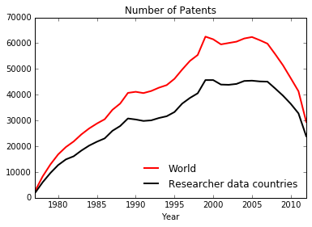

```python
%matplotlib inline
# plot the total number of patents granted to inventors from the world
patents_granted_EPO.loc['WLD'].Patents.plot(color='r',linewidth=2,label='World')
# plot the total number of patents granted to the inventors from the countries in the researcher data
patents_granted_EPO.loc[country_list].groupby(level=1)['Patents'].sum().plot(color='k',linewidth=2,label='Researcher data countries')
plt.legend(loc='best',frameon=False)
plt.title('Number of Patents')
```

```python
# merge the two datasets
patents_researchers = patents_granted_EPO.reset_index().merge(full_time_researchers.reset_index(),how='left',on=['COUNTRY','Country','Year']).set_index(['COUNTRY','Year'])
```

```python
# our merged data looks like this
patents_researchers.head()
```

| COUNTRY | Year | Country | Patents | Researchers |
| --- | --- | --- | --- | --- |
| AUS | 1977 | Australia | 21.0000 | NaN |
|  | 1978 | Australia | 59.2500 | NaN |
|  | 1979 | Australia | 75.6667 | NaN |
|  | 1980 | Australia | 99.0000 | NaN |
|  | 1981 | Australia | 103.9500 | 24208.0 |

As you see above, we have many missing obsevations in the researcher data. We need to interpolate it. Say, for a country $i$, we hava data for years $t_1$ and $t_2$ with number of researchers equal to $y_{1}$ and $y_{2}$ respectively. Then for any $t_0$ such that $t_1 \leq t_0\leq t_2$, the interpolated number of researchers $y_0$ at time $t_0$ is equal to $$y_0 = y_1\frac{t_2-t_0}{t_2-t_1} + y_2\frac{t_0-t_1}{t_2-t_1}.$$

- Don't interpolate the missing observations before the first available observation.
- Don't interpolate the missing observations after the last available observation.

```python
# interpolate the researcher data
patents_researchers['Researchers (interpolated)']=patents_researchers.groupby(level=0)['Researchers'].apply(lambda group:group.interpolate(limit_area='inside'))
```

```python
# interpolated data looks like this
patents_researchers.head(10)
```

| COUNTRY | Year | Country | Patents | Researchers | Researchers (interpolated) |
| --- | --- | --- | --- | --- | --- |
| AUS | 1977 | Australia | 21.0000 | NaN | NaN |
|  | 1978 | Australia | 59.2500 | NaN | NaN |
|  | 1979 | Australia | 75.6667 | NaN | NaN |
|  | 1980 | Australia | 99.0000 | NaN | NaN |
|  | 1981 | Australia | 103.9500 | 24208.0 | 24208.000000 |
|  | 1982 | Australia | 114.6000 | NaN | 25730.666667 |
|  | 1983 | Australia | 137.5095 | NaN | 27253.333333 |
|  | 1984 | Australia | 152.6833 | 28776.0 | 28776.000000 |
|  | 1985 | Australia | 155.4167 | 29866.0 | 29866.000000 |
|  | 1986 | Australia | 157.4286 | 35029.0 | 35029.000000 |

```python
patents_researchers.loc[country_list].Country.unique()
```

```
array(['Australia', 'Austria', 'Belgium', 'Canada', 'Czech Republic',
       'Denmark', 'Finland', 'France', 'Germany', 'Greece', 'Hungary',
       'Iceland', 'Ireland', 'Italy', 'Japan', 'Luxembourg', 'Mexico',
       'Netherlands', 'Norway', 'Poland', 'Portugal', 'Slovak Republic',
       'Spain', 'Sweden', 'Switzerland', 'Turkey', 'United Kingdom',
       'Argentina', 'Chile', "China (People's Republic of)", 'Estonia',
       'Latvia', 'Romania', 'Russia', 'Singapore', 'Slovenia',
       'Chinese Taipei'], dtype=object)
```

```python
patents_researchers.to_csv('patents-researchers.csv')
```

```python
# Now sum over countries
# total number of patents granted to countries in the world
total_patents_researchers = pd.DataFrame(patents_researchers.loc['WLD'].Patents).rename(columns={'Patents':'Patents (World)'})
# total number of patents granted to countries listed in the researcher data
total_patents_researchers['Patents (small set)'] = patents_researchers.loc[country_list].groupby(level=1).Patents.sum()
# total number of researchers
total_patents_researchers['Researchers (interpolated)'] = patents_researchers.loc[country_list].groupby(level=1)['Researchers (interpolated)'].sum()
# Growth rate of patents (World)
total_patents_researchers['Patent growth (World)'] =total_patents_researchers['Patents (World)'].pct_change()
# Growth rate of patents (countrie in the researcher data)
total_patents_researchers['Patent growth (small set)'] =total_patents_researchers['Patents (small set)'].pct_change()
# Growth rate of researchers
total_patents_researchers['Researcher growth'] =total_patents_researchers['Researchers (interpolated)'].pct_change()
```

```python
total_patents_researchers['Patent growth (World)'] =total_patents_researchers['Patents (World)'].pct_change()
```

```python
# this is our data summed over countries
total_patents_researchers.head(10)
```

| Year | Patents (World) | Patents (small set) | Researchers (interpolated) | Patent growth (World) | Patent growth (small set) | Researcher growth |
| --- | --- | --- | --- | --- | --- | --- |
| 1977 | 2505.0 | 1808.1903 | 0.000000 | NaN | NaN | NaN |
| 1978 | 8280.0 | 6013.2999 | 0.000000 | 2.305389 | 2.325590 | NaN |
| 1979 | 12936.0 | 9615.2532 | 0.000000 | 0.562319 | 0.598998 | NaN |
| 1980 | 16838.0 | 12692.4413 | 0.000000 | 0.301639 | 0.320032 | NaN |
| 1981 | 19693.0 | 14896.4243 | 532036.000000 | 0.169557 | 0.173645 | inf |
| 1982 | 21852.0 | 16101.0151 | 553892.916667 | 0.109633 | 0.080864 | 0.041082 |
| 1983 | 24613.0 | 18332.5035 | 580338.833333 | 0.126350 | 0.138593 | 0.047746 |
| 1984 | 26917.0 | 20258.5024 | 602463.202381 | 0.093609 | 0.105059 | 0.038123 |
| 1985 | 28821.0 | 21759.5628 | 625705.904762 | 0.070736 | 0.074095 | 0.038579 |
| 1986 | 30477.0 | 23043.5252 | 659437.607143 | 0.057458 | 0.059007 | 0.053910 |

```python
total_patents_researchers.to_csv('total_patents_researchers.csv')
```

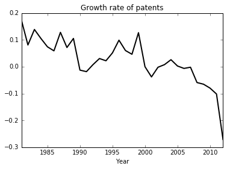

```python
total_patents_researchers.loc[1981:2012]['Patent growth (small set)'].plot(color='k',linewidth=2)
plt.title('Growth rate of patents')
```

```python
# Total number of researchers in 1985 and 2005
total_patents_researchers.loc[(1985,2005),:]['Researchers (interpolated)'].round()
```

```
Year
1985     625706.0
2005    4067330.0
Name: Researchers (interpolated), dtype: float64
```

```python
# Total number of patents in 1985 and 2005 granted to the inventors from the World
total_patents_researchers.loc[(1985,2005),:]['Patents (World)'].round()
```

```
Year
1985    28821.0
2005    62403.0
Name: Patents (World), dtype: float64
```

```python
# Total number of patents in 1985 and 2005 granted to the inventors from the countries in the researcher data
total_patents_researchers.loc[(1985,2005),:]['Patents (small set)'].round()
```

```
Year
1985    21760.0
2005    45459.0
Name: Patents (small set), dtype: float64
```

```python
# Growth rate of number of patents granted to inventor from countries listed in the researcher data in 1985 and 2004
(total_patents_researchers.loc[(1986,2005),:]['Patent growth (small set)']).round(decimals=3)
```

```
Year
1986    0.059
2005    0.003
Name: Patent growth (small set), dtype: float64
```

Answering part f is quite tricky. In our formula, we have $\hat{A} \equiv \frac{\dot{A}}{A} = \frac{L_A}{\mu}$. The question basically asks us whether $\mu$ is a constant or a function of technology $A$? We observe number of researchers in the data, hence $L_A$ is easy to find. However, we still don't know what $\frac{\dot{A}}{A}$ is. We can make one of these assumptions and conduct our analysis:

a. $\frac{\dot{A}}{A}$ is equal to the number of patents granted at each year. This basically a normalization as we don't what $A$ is. If we go with this assumption, for our formulate to hold, the number of patents over the number of researchers should be constant over time as $\frac{\frac{\dot{A}}{A}}{L_A} = {\mu}$

b. $\dot{A}$ is equal to the number of new patents. Then, what is A?

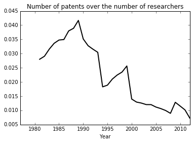

```python
# Let's analyze case a.
(total_patents_researchers['Patents (small set)']/total_patents_researchers['Researchers (interpolated)']).plot(color='k',linewidth=2)
plt.title('Number of patents over the number of researchers')
```

In this case, since the number of patents over the number of researchers are going down, we find evidence agianst $\mu$ is constant.

How should we analyze case b? Suppose $A(t)$ is the total number of patents granted until time t. Suppose our formulation is true, then $\frac{\dot{A}(t)}{A(t)}$ should increase as $L_A(t)$ increases in our data. For $\frac{\dot{A}(t)}{A(t)}$ to increase over time, number of new patents at each year should increase at an increasing rate. However, as shown the growth rate of patents, number of new patents are increasing at a decreasing rate.